# Module 2, Part 1: Statistical Learning

TMA4268 Statistical Learning V2022

Sara Martino, Department of Mathematical Sciences, NTNU

January 17, 2022

# Acknowledgements

- A lot of this material stems from Mette Langaas and her TAs (especiall Julia Debik). I would like to thank Mette for the permission to use her material!
- Some of the figures and slides in this presentation are taken (or are inspired) from @ISL.

# Introduction

## Learning material for this module

$~$

- James et al (2013): An Introduction to Statistical Learning. Chapter 2 (except 2.2.3).
- Additional material (in this module page) on random variables, covariance matrix and the multivariate normal distribution (known for students who have taken TMA4267 Linear statistical models).

## What will you learn?

- Statistical learning and examples thereof
- Introduce relevant notation and terminology
- Prediction accuracy vs. model interpretability
- Bias-variance trade-off
- The basics of random vectors, covariance matrix and the multivariate normal distribution.

# What is statistical learning?

## Two variable types

**Quantitative** variables are variables from a continuous set, they have a numerical value.

- Examples: a person’s weight, a company’s income, the age of a building, the temperature outside, the level of precipitation etc.

**Qualitative** variables are variables from a discrete set with $K$ different classes/labels/categories.

- Examples: type of fruit {apples, oranges, bananas, …}, sex {male, female, other }, education level {none, low, medium, high}.
- Qualitative variables which have only two classes are called *binary* variables and are usually coded by 0 (no) and 1 (yes).

# Examples of learning problems

- Predict the price of a stock 3 months from now, based on company performance measures and economic data. The response variable is quantitative (price). *Continuous outcome*.
- Spam detection for emails. *Binary outcome* (yes, no).
- Identification of risk factors for Prostate cancer. *Binary outcome* (yes, no).
- Estimating the risk of heart disease or heart attack, given knowledge about condition, behaviour, age, or demographic, diet and clinical measurements. *Binary outcome* (yes, no).
- Digit and image recognition. *Categorical outcome*.

### Example 1: Handwritten digit recognition

- Aim: To identify the numbers in a handwritten ZIP code, from a digitized image.
- Classification problem with categorical response variable {0, 1, 2, …, 9}.

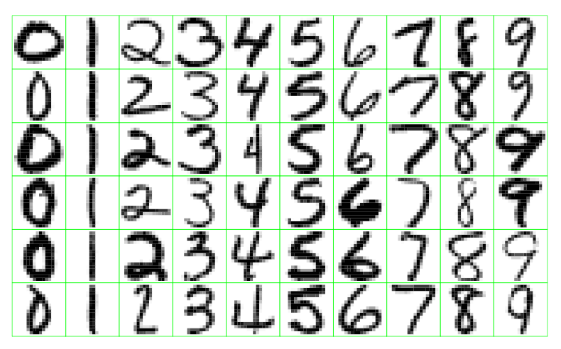

Examples of handwritten digits from U.S. postal envelopes. Image taken from https://web.stanford.edu/~hastie/ElemStatLearnII/

### Example 2: Email classification (spam detection)

$~$

- Goal: to build a spam filter.
- This filter can based on the frequencies of words and characters in emails.

$~$

The table below shows the average percentage of words or characters in an email message, based on 4601 emails of which 1813 were classified as a spam.

|  | you | free | george | ! | $ | edu |
| --- | --- | --- | --- | --- | --- | --- |
| not spam | 1.27 | 0.07 | 1.27 | 0.11 | 0.01 | 0.29 |
| spam | 2.26 | 0.52 | 0.00 | 0.51 | 0.17 | 0.01 |

# The Supervised Learning Problem

- Outcome measurement $Y$, also called dependent variable, response, target.
- Vector of $p$ predictor measurements $X=(X_1,\ldots,X_p)$, also called inputs, regressors, covariates, features, independent variables.
- In the **regression problem**, $Y$ is quantitative (e.g price, blood pressure).
- In the **classification problem**, $Y$ takes values in a finite, unordered set (survived/died, digit 0-9, cancer class of tissue sample).
- We have training data $(x_1, y_1), \ldots , (x_N , y_N )$. These are observations (examples, instances) of these measurements.

## Supervised learning and its objectives

Our data set (training set) consists of $n$ measurement of the response variable $Y$ and of $p$ covariates $x$:
$$(y_1,
x_{11}, x_{12},\ldots, x_{1p}), (y_2, x_{21},\ldots, x_{2p}), \ldots,
(y_n, x_{n1}, x_{n2},\ldots, x_{np}).$$
$~$

- **accurately predict** unseen test cases.
- **understand** which input affects the outcomes, and how.
- **assess the quality** of your predictions and inference.

The majority of problems studied in this course fall in the supervised learning category (exception: Module 10)

# Notation and key statistical concepts

See notes and p. 9–12 in the course book.

# The Unsupervised Learning Problem

- There is **no outcome variable** $y$, just a set of predictors (features) $x_i$ measured on a set of samples.
- Objective is more fuzzy – find (hidden) patterns or groupings in the data - in order to *gain insight and understanding*. There is no *correct* answer.
- Difficult to know how well your are doing.

$~$

Examples in the course:

- Clustering (M10)
- Principal component analysis (M10)

# Overall philosophy

- Important to understand the simpler methods first, in order to grasp the more sophisticated ones.

$\rightarrow$ **Simpler methods often perform as well as fancier ones!**

$~$

- It is important to accurately *assess the performance of a method*, to know how well or how badly it is working.

# Statistical Learning vs. Machine Learning

- Machine learning arose as a subfield of Artificial Intelligence.
- Statistical learning arose as a subfield of Statistics.
- There is much overlap – both fields focus on supervised and unsupervised problems:
  - Machine learning has a greater emphasis on large scale applications and prediction accuracy.
  - Statistical learning emphasizes models and their interpretability, and precision and uncertainty.
- The distinction has become more and more blurred, and there is a great deal of “cross-fertilization”.
- Machine learning has the upper hand in Marketing!
- There is a controversy and some scepticism against ``too fancy’’ ML methods.
- Criticism: ML often re-invents existing methods and names them differently, but often without awareness of existing methods in statistics.
- Almost weekly new literature that delivers comparison. Often, the “simple” statistical methods “win”.

[figure not shown]

ML vs statistics controversy

A tweet by one of the co-authors of the course book, coincidentially…

[figure not shown]

## What is the aim in statistical learning?

We are talking about supervised methods now. Assume:

- we observe one *quantitative* response $Y$ and $p$ different predictors $x_1, x_2,... , x_p$.
- We assume that there is a function $f$ that relates the response and the predictor variables:
  $$Y = f(x) +
  \varepsilon,$$
  where $\varepsilon$ is a random error term with mean 0 and independent of $x$.

$~$

# Example 1

Sales of a product, given advertising budgets in different media.

[figure not shown]

ISLR Figure 2.12

# Example 2

Income for given levels of education.

[figure not shown]

ISLR Figure 2.12

There are two main reasons for estimating $f$:

- **Prediction**
- **Inference**

## Reason 1: Prediction

$~$

**Aim**: predict a response $Y$ given new observations $x$ of the covariates as accurately as possible.

$~$

Notation:

$$\hat{Y} = \hat{f}(x).$$

- $\hat{f}$: estimated $f$
- $\hat{Y}$ prediction for $Y$ given $x$.
- We *do not really care* about the shape of $f$ (“black box”).  
  $\rightarrow$ no interpretation of regression parameters when the aim is purely prediction!

There are two quantities which influence the accuracy of $\hat{Y}$ as a prediction of $Y$:

For a given $\hat{f}$ and a set of predictors $X$ which gives $\hat{Y}=\hat{f}(X)$, we have

$$\text{E}[(Y-\hat{Y})^2] =
\underbrace{(f(X)-\hat{f}(X))^2}_{reducible} +
\underbrace{\text{Var}(\epsilon)}_{irreducible}$$

### Q: If there were a *deterministic* relationship between the response and a set of predictors, would there then be both reducible and irreducible error?

## Reason 2: Inference

$~$

**Aim**: understand *how* the response variable is affected by the various predictors (covariates).

$~$

The *exact form* of $\hat{f}$ is of *main interest*.

- Which predictors are associated with the response?
- What is the relationship between the response and each predictor?
- Can the relationship be linear, or is a more complex model needed?

# Estimating $f$

Overall idea:

- Using available *training data* $(x_1,y_n),\ldots (x_n,y_n)$ to estimate $\hat{f}$, such that $Y\approx \hat{f}(X)$ for any $(X,Y)$ (also those that have not yet been observed).

$~$

- Parametric methods
- Non-parametric methods

## Parametric methods

$~$

Asumption about the form or shape of the function $f$.

The multiple linear model (M3) is an example of a parametric method:

$$f(x) = \beta_0 + \beta_1 x_1 + ... +
\beta_p x_p+\varepsilon \ ,$$

with $\varepsilon \sim N(0,\sigma^2)$.

$~$

The task simplifies to finding estimates of the $p+1$ coefficients $\beta_0, \beta_1, .. ,\beta_p$. To do this we use the training data to fit the model, such that
$$Y \approx \hat{\beta_0} + \hat{\beta_1} x_1 + ...
+ \hat{\beta_p} x_p \ .$$

Fitting a parametric models is thus done in two steps:

1. Select a form for the function $f$.
2. Estimate the unknown parameters in $f$ using the training set.

## Non-parametric methods

$~$

- Non-parametric methods seek an estimate of $f$ that gets close to the data points, but without making explicit assumptions about the form of the function $f$.
- Example: $K$-nearest neighbour (KNN) algorithm, used in classification. KNN predicts a class membership for a new observation by making a majority vote based on its $K$ nearest neighbours. We will discuss the $K$-nearest neighbour algorithm in Module 4.

### KNN example

$~$

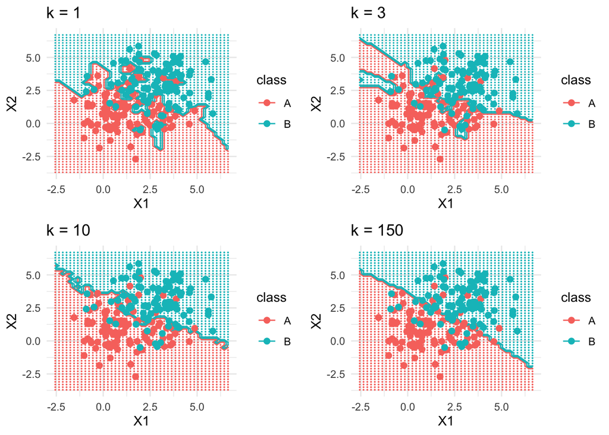

### Parametric methods

| Advantages | Disadvantages |
| --- | --- |
| Simple to use and easy to understand | The function $f$ is constrained to the specified form. |
| Requires little training data | The assumed function form of $f$ will in general not match the true function, potentially giving a poor estimate. |
| Computationally cheap | Limited flexibility |

### Non-parametric methods

| Advantages | Disadvantages |
| --- | --- |
| Flexible: a large number of functional forms can be fitted | Can overfit the data |
| No strong assumptions about the underlying function are made | Computationally more expensive as more parameters need to be estimated |
| Can often give good predictions | Much data are required to estimate (the complex) $f$. |

# Prediction accuracy vs. interpretability

(we are warming up to the bias–variance trade–off)

**Inflexible** methods:

- Linear regression (M3)
- Linear discriminant analysis (M4)
- Subset selection and lasso (M6)

**Flexible** methods:

- KNN classification (M4), KNN regression, Smoothing splines (M7)
- Bagging and boosting (M8), support vector machines (M9)
- Neural networks (M11)

## Why would I ever prefer an inflexible method?

$~$

Example: Prediction of icome from “Years of Education” and “Seniority”

[figure not shown]

A linear model vs a perfect fit.

$~$

**Potential problems:**

**Overfitting** occurs when the estimated function $f$ is too closely fit to the observed data points.

**Underfitting** occurs when the estimated function $f$ is too rigid to capture the underlying structure of the data.

$~$

*We illustrate this by a toy example using polynomial regression.*

## Polynomial regression example (simulation)

Consider a covariate $x$ observed between $x=-2, \ldots , 4$ and $n=61$ observations.

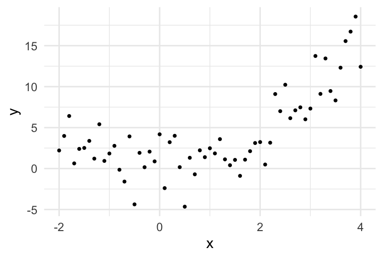

We impose a relationship between reponse $Y$ and covariate $x$

$$Y=x^2 + \varepsilon$$

with error (noise) term $\varepsilon\sim N(0,\sigma^2)$ with $\sigma=2$. It is a substitue for all the unobserved variables that are not in our equation, but that might influence $Y$.

- We call $Y=x^2$ the *truth*.
- $\varepsilon$ is the *irreducible error*.

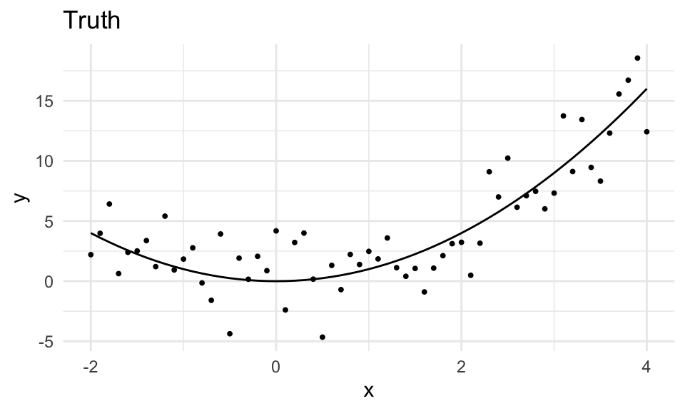

Try to fit a function to the observations *without* knowing the true relationship:

$~$

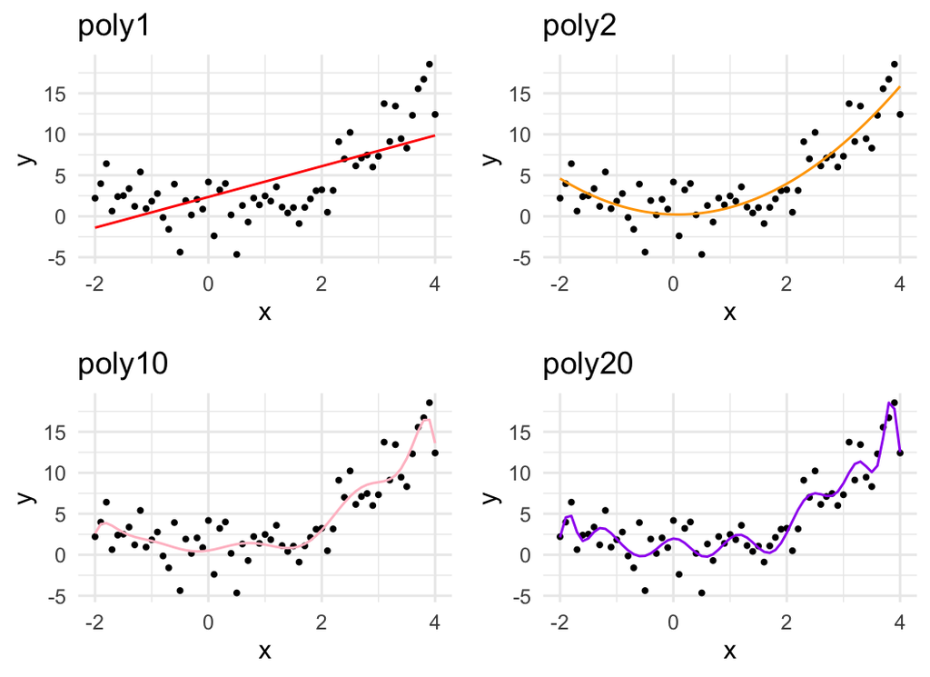

The degree of the polynomial is a *flexibility parameter*.

We can now ask:

- Which of these models performs “best”?
- Is there *one* method that dominates all others?

# Assessing model accuracy

**No method** dominates all others over all possible data sets.

- That is why we need to learn about many different methods.
- For a given data set we need to know how to decide which method produces the *best* results.
- We need to understand what *best* means.
- How close is the predicted response to the true response value?

## Measuring the Quality of Fit

The quality of fit can be measures as the *Training MSE* (mean squared error), using the data that were used to estimate $f$:

$$\text{MSE}_{\text{train}}=\frac{1}{n}\sum_{i=1}^n
(y_i-\hat{f}(x_i))^2$$
$~$

Why is the training MSE not the real measure of interest?

$~$

Examples:

- We don’t want to predict last weeks stock price, we want to predict the stock price next week.
- We don’t want to predict if a patient in the training data has diabetes (because we already know this), we want to predict if a new patient has diabetes.

### Training error for the polynomial example

$~$

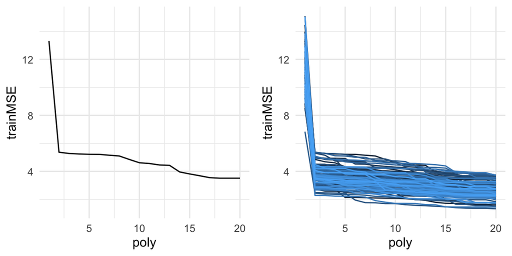

Left: one repetition, right: 100 repetitions of the training set.

**Q**: Based on the training MSE - which model fits the data the best?

## Test MSE

$~$

- Simple solution: estimate $\hat{f}$ using the training data (maybe my minimizing the training MSE), but choose the *best* model using a separate *test set*.
- *Test MSE* for a set of $n_0$ test observations $(x_{0j},y_{0j})$:

$$\text{MSE}_{\text{test}}=\frac{1}{n_0}\sum_{j=1}^{n_0}
(y_{0j}-\hat{f}(x_{0j}))^2$$

- Alternative notation:
  $$\text{Ave}(y_0-\hat{f}(x_0))^2$$
  (taking the average over all available test observations).

### Test error for the polynomial example

$~$

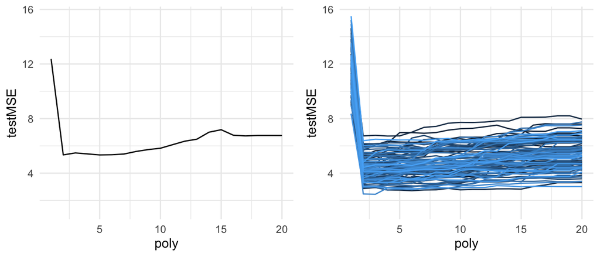

Left: one repetition, right: 100 repetitions for the testMSE.

### Questions:

$~$

**Q1**: Based on the test MSE - which model fits the data the best?

**Q2:** What if we do not have access to test data?

**Q3:** Can we instead just use the training data MSE to choose a model? A low training error should also give a low test error?

**Q4:** Important observation:

- The test error seems to have a minimum (U-shape) in between the extremes.
- The training error keeps going down.

Why?

# The Bias-Variance trade-off

The U-shape is the result of *two competing properties* of statistical learning methods.

$~$

- Compare this to the test MSE for the polynomical example ($\text{MSE}_{\text{test}}$): The average is simply replaced by the *theoretical version* (expected value).

Using that $y_0=f(x_0)+\varepsilon$, this expected test MSE (at $X=x_0$) can be decomposed into three terms (board)
$$\begin{align*}
&\text{E}[(y_0 - \hat{f}(x_0))^2] = \\
& ... \\
& = \underbrace{\text{Var}(\varepsilon)}_{\text{Irreducible error}}
+ \underbrace{\text{Var}(\hat{f}(x_0))}_{\text{Variance of prediction}}
+ \underbrace{\left( f(x_0) - \text{E}[\hat{f}(x_0)]
\right)^2}_{\text{Squared bias}}
\end{align*}$$

$$\text{E}[(y_0 -
\hat{f}(x_0))^2]=\cdots=\text{Var}(\varepsilon)
+ \text{Var}(\hat{f}(x_0))+[\text{Bias}(\hat{f}(x_0))]^2$$

### General rule

For more flexible models, the variance will *increase* and the bias will *decrease*.

### Choosing the best model

$~$

The aim is often to obtain **the most predictive model**. Ingredients:

1. **Training set**: The observations used to fit the statistical model $\rightarrow$ Training error
2. **Test sample**: new observations which were not used when fitting the model $\rightarrow$ Test error

We have seen that

- Training error decreases for more complex/flexible models, but the test error has an **optimum**.

$\rightarrow$ **Bias-Variance trade-off**

[figure not shown]

ISLR Figure 2.12

### Polynomial example (cont.)

See recommended exercise 2.

$Y=x^2$ is still the *truth*.

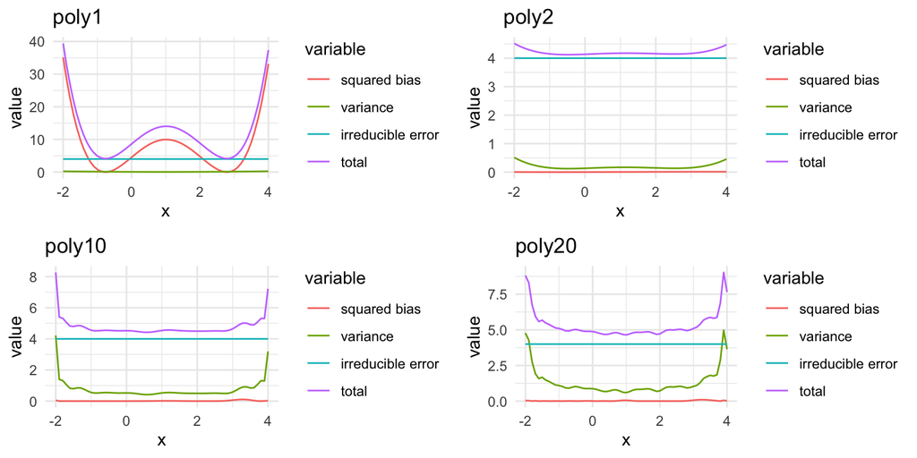

For four different polynomial models (poly1,2,10 and 20), the squared bias, variance, irreducible error and the total sum. Plots based on 100 simulations for the polynomial example.

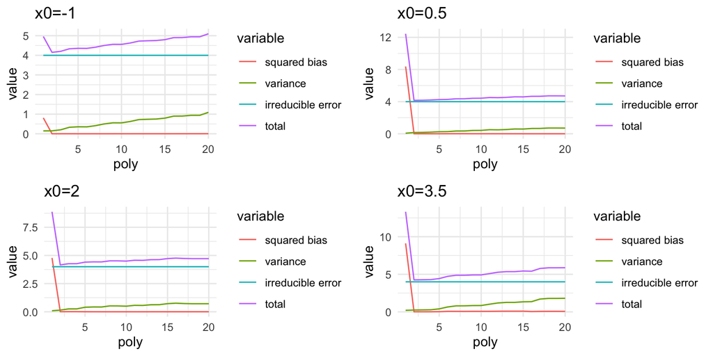

At four different values for $x_0$, the squared bias, variance, irreducible error and the total sum. Plots based on 100 simulations for the polynomial example.

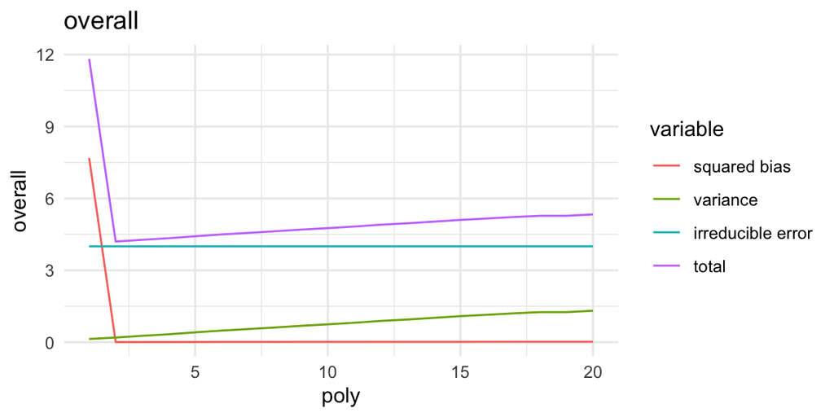

Overall version (averaging over 61 gridpoints of $x$).